# 6306-404 Assignment

Hayley Horn

October 28, 2018

### Background

Brewmeisters in Colorado and Texas have teamed up to analyze the relationship between ABV and IBU in each of their states. Use the data sets from the project to help them in their analysis.

There three main questions of interest are:  
1) Is there a significant linear relationship between ABV (response) and IBU (explanatory)  
2) Is this relationship different between beers in Colorado and Texas  
3) Is there a significant quadratic component in this relationship for either Colorado or Texas or both?

**Clean and prepare the data:**

```r
#Load the data
Beers <- read.csv("C:/Users/ha406272/Desktop/6306/Unit9/Beers.csv")
Brews <- read.csv("C:/Users/ha406272/Desktop/6306/Unit9/Breweries.csv")
```

1. Create column for brewery ID that is common to both datasets similar to what you did in the project. So we can merge!

```r
names(Beers) <- c("Beer_Nm","Beer_ID","ABV","IBU","Brew_ID","Style","Ounces") #We renamed the fields for consistency and easier linking. Linking 2 data sets with the same field names is simpler.
```

2. Merge the beer and brewery data into a single dataframe.

```r
BandBs <- (merge(Beers,Brews, by = "Brew_ID"))    #This small bit of code merges the data sets.
BandBs$IBU <- as.numeric(BandBs$IBU)              #Make IBU numeric
BandBs$ABV <- as.numeric(BandBs$ABV)              #Make ABV numeric
BandBs <- BandBs[complete.cases(BandBs), ]        #Remove NAs
#str(BandBs)
#summary(BandBs)
```

3. Clean the State Column . get rid of extraneous white space.

```r
BandBs$State = trimws(BandBs$State, "l") #First, remove whitespace from the data.
```

4. Create One Dataset that has only Colorado and Texas beers and no IBU NAs . name it “beerCOTX”

```r
#beerCOTX <- subset(BandBs, BandBs$State == c("CO","TX"))
beerCOTX = subset(BandBs,(BandBs$State == "CO" | BandBs$State == "TX") & !is.na(IBU))
```

5. Order beerCOTX by IBU (ascending) … this will be important later in graphing

```r
#Order by IBU
beerCOTX <- beerCOTX[order(beerCOTX$IBU),]
```

**Create an initial plots of the data**  
6. Plot ABV v. IBU for both Colorado and Texas using ggplot and facets.

[figure not shown]

**Model the data**

7. For each state, fit a simple linear regression model to assess the relationship between ABV and IBU. Use the regular plot function in base R (not ggplot) to create a scatter plot with the regression line superimposed on the plot. Again, this should be done for each state.

Colorado

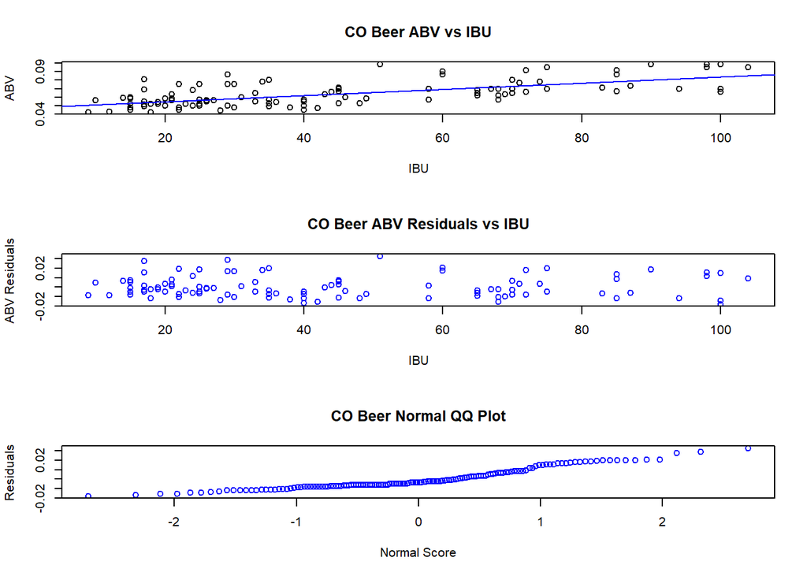

```r
par(mfrow=c(3,1))                                                           #Set plot area to 3x1
beerCO = subset(beerCOTX,beerCOTX$State == "CO" & !is.na(IBU))                            #Subset CO data
beerCO <- beerCO[order(beerCO$IBU),]
beerCOlm <- lm(beerCO$ABV ~ beerCO$IBU)                                     #Linear Model
#visualize CO lm data and residuals
plot(beerCO$IBU,beerCO$ABV,ylab="ABV",xlab="IBU",main="CO Beer ABV vs IBU") #Plot CO abv vs ibu
abline(beerCOlm, col = "Blue")                                              #Regression line
beerCOresid=resid(beerCOlm)                                                 #Residuals
plot(beerCO$IBU,beerCOresid,ylab="ABV Residuals",xlab="IBU",
                        main="CO Beer ABV Residuals vs IBU", col = "Blue") #Plot CO residuals
qqnorm(beerCOresid,ylab="Residuals",xlab="Normal Score",
                        main="CO Beer Normal QQ Plot", col = "Blue")       #QQPlot CO residuals
```

Texas

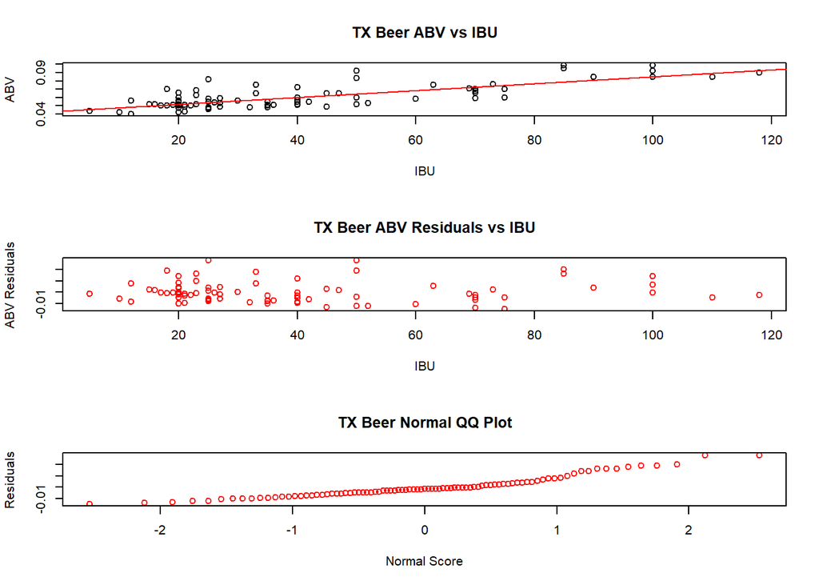

```r
par(mfrow=c(3,1))                                                           #Set plot area to 3x1
beerTX = subset(beerCOTX,beerCOTX$State == "TX" & !is.na(IBU))             #subset TX data
beerTX <- beerTX[order(beerTX$IBU),]
beerTXlm <- lm(beerTX$ABV ~ beerTX$IBU)                                     #Linear Model
#visualize CO lm data and residuals
plot(beerTX$IBU,beerTX$ABV,ylab="ABV",xlab="IBU",main="TX Beer ABV vs IBU") #Plot TX abv vs ibu
abline(beerTXlm, col = "Red")                                               #Regression line
beerTXresid=resid(beerTXlm)                                                 #Residuals
plot(beerTX$IBU,beerTXresid,ylab="ABV Residuals",xlab="IBU",
                        main="TX Beer ABV Residuals vs IBU", col = "Red")   #Plot TX residuals
qqnorm(beerTXresid,ylab="Residuals",xlab="Normal Score",
                        main="TX Beer Normal QQ Plot", col = "Red")         #QQPlot TX residuals
```

8. Address the assumptions of the regression model:  
1) There is a normal distribution of the ABV for fixed values of IBU.  
The CO and TX Beer ABV vs IBU plots appear to demonstrate normality 2) These normal distributions have equal standard deviations.  
The CO and TX Beer QQplots show little evidence of unequal standard deviations. 3) The means of these normal distributions have a linear relationship with IBU.  
The data have a positive linear trend. 4) The data are assumed to be Independent

**Gain Inference from the Table**  
9. Make sure and print the parameter estimate table.

```r
#Colorado Parameter Estimate Table
summary(beerCOlm)
```

```
##
## Call:
## lm(formula = beerCO$ABV ~ beerCO$IBU)
##
## Residuals:
##       Min        1Q    Median        3Q       Max
## -0.018158 -0.007266 -0.003293  0.006453  0.032853
##
## Coefficients:
##              Estimate Std. Error t value Pr(>|t|)
## (Intercept) 4.740e-02  1.856e-03   25.54   <2e-16 ***
## beerCO$IBU  3.676e-04  3.432e-05   10.71   <2e-16 ***
## ---
## Signif. codes:  0 '***' 0.001 '**' 0.01 '*' 0.05 '.' 0.1 ' ' 1
##
## Residual standard error: 0.01077 on 144 degrees of freedom
## Multiple R-squared:  0.4433, Adjusted R-squared:  0.4395
## F-statistic: 114.7 on 1 and 144 DF,  p-value: < 2.2e-16
```

```r
#Texas Parameter Estimate Table
summary(beerTXlm)
```

```
##
## Call:
## lm(formula = beerTX$ABV ~ beerTX$IBU)
##
## Residuals:
##       Min        1Q    Median        3Q       Max
## -0.014764 -0.005738 -0.001560  0.003182  0.028096
##
## Coefficients:
##              Estimate Std. Error t value Pr(>|t|)
## (Intercept) 4.347e-02  1.772e-03   24.54   <2e-16 ***
## beerTX$IBU  4.172e-04  3.683e-05   11.33   <2e-16 ***
## ---
## Signif. codes:  0 '***' 0.001 '**' 0.01 '*' 0.05 '.' 0.1 ' ' 1
##
## Residual standard error: 0.009078 on 87 degrees of freedom
## Multiple R-squared:  0.596,  Adjusted R-squared:  0.5914
## F-statistic: 128.3 on 1 and 87 DF,  p-value: < 2.2e-16
```

```r
#Colorado COnfidence Interval at alpha = .05
confint(beerCOlm,level = .95)
```

```
##                   2.5 %       97.5 %
## (Intercept) 0.043732505 0.0510700022
## beerCO$IBU  0.000299726 0.0004354124
```

```r
#Texas COnfidence Interval at alpha = .05
confint(beerTXlm,level = .95)
```

```
##                   2.5 %       97.5 %
## (Intercept) 0.039952379 0.0469949413
## beerTX$IBU  0.000344007 0.0004903987
```

```r
#Add new column called IBU2
beerCOTX <- within(beerCOTX, IBU2 <- beerCOTX$IBU*beerCOTX$IBU)
#Print head of file
head(beerCOTX)
```

```
##      Brew_ID               Beer_Nm Beer_ID   ABV IBU
## 462       67    Yo Soy Un Berliner    2520 0.044   5
## 754      129 18th Anniversary Gose    2370 0.044   5
## 1944     392           Agave Wheat    1522 0.042   9
## 280       38          White Rascal     108 0.056  10
## 460       67               Rye Wit    2522 0.042  10
## 1124     188             Lobo Lito    2238 0.040  12
##                        Style Ounces                       Name
## 462       Berliner Weissbier     12   Freetail Brewing Company
## 754                     Gose     12   Real Ale Brewing Company
## 1944 American Pale Wheat Ale     12       Breckenridge Brewery
## 280                  Witbier     12      Avery Brewing Company
## 460                  Witbier     12   Freetail Brewing Company
## 1124             Light Lager     12 Pedernales Brewing Company
##                City State IBU2
## 462     San Antonio    TX   25
## 754          Blanco    TX   25
## 1944         Denver    CO   81
## 280         Boulder    CO  100
## 460     San Antonio    TX  100
## 1124 Fredericksburg    TX  144
```

```r
summary(beerCOTX)
```

```
##     Brew_ID                            Beer_Nm       Beer_ID
##  Min.   :  7.0   Dale's Pale Ale           :  4   Min.   :   1.0
##  1st Qu.:119.0   Bombshell Blonde          :  2   1st Qu.: 696.5
##  Median :167.0   Fat Tire Amber Ale        :  2   Median :1333.0
##  Mean   :214.2   Firestarter India Pale Ale:  2   Mean   :1327.1
##  3rd Qu.:293.5   Mama's Little Yella Pils  :  2   3rd Qu.:2070.5
##  Max.   :524.0   Modus Hoperandi           :  2   Max.   :2644.0
##                  (Other)                   :221
##       ABV               IBU                                    Style
##  Min.   :0.04000   Min.   :  5.00   American Pale Ale (APA)       : 34
##  1st Qu.:0.05200   1st Qu.: 22.00   American IPA                  : 32
##  Median :0.06000   Median : 35.00   American Double / Imperial IPA: 19
##  Mean   :0.06313   Mean   : 44.77   American Amber / Red Ale      : 14
##  3rd Qu.:0.07000   3rd Qu.: 65.00   American Blonde Ale           : 11
##  Max.   :0.09900   Max.   :118.00   Saison / Farmhouse Ale        :  7
##                                     (Other)                       :118
##      Ounces                                 Name               City
##  Min.   :12.00   Oskar Blues Brewery          : 32   Boulder     : 26
##  1st Qu.:12.00   New Belgium Brewing Company  : 12   Longmont    : 20
##  Median :12.00   Southern Star Brewing Company: 12   Denver      : 17
##  Mean   :13.02   Karbach Brewing Company      : 10   Fort Collins: 17
##  3rd Qu.:12.00   Bonfire Brewing Company      :  8   Austin      : 13
##  Max.   :19.20   Upslope Brewing Company      :  8   Houston     : 13
##                  (Other)                      :153   (Other)     :129
##     State                IBU2
##  Length:235         Min.   :   25
##  Class :character   1st Qu.:  484
##  Mode  :character   Median : 1225
##                     Mean   : 2693
##                     3rd Qu.: 4225
##                     Max.   :13924
##
```

12. For each state, create a training and test set from the data (60%/40% split respectively). Print a summary of each new data frame. there should be four: TrainingCO, TestCO, TrainingTX, TestTX.

```r
#Divide CO data into training and test set into 60%/%40 training/test
samplesizeCO = nrow(filter(beerCOTX,beerCOTX$State == "CO" & !is.na(beerCOTX$IBU)))
train_percent = .6
# CO random training data from original data
train_indicesCO = sample(seq(1,samplesizeCO,length = samplesizeCO),train_percent*samplesizeCO)
trainCO = subset(beerCOTX,beerCOTX$State == "CO" & !is.na(IBU))[train_indicesCO,]
# CO random test data from original data
testCO = subset(beerCOTX,beerCOTX$State == "CO" & !is.na(IBU))[-train_indicesCO,]
```

Summary for Colorado Training Set

```r
#CO Summary for Training Set
summary(trainCO)
```

```
##     Brew_ID                            Beer_Nm      Beer_ID
##  Min.   :  7.0   Dale's Pale Ale           : 3   Min.   :   4
##  1st Qu.:110.2   Firestarter India Pale Ale: 2   1st Qu.: 669
##  Median :167.0   5:00 O'Clock Afternoon Ale: 1   Median : 910
##  Mean   :250.1   Agave Wheat               : 1   Mean   :1097
##  3rd Qu.:422.0   American India Red Ale    : 1   3rd Qu.:1521
##  Max.   :524.0   (Other)                   :80   Max.   :2644
##  NA's   :53      NA's                      :53   NA's   :53
##       ABV               IBU                                    Style
##  Min.   :0.04200   Min.   :  9.00   American Pale Ale (APA)       :16
##  1st Qu.:0.05200   1st Qu.: 23.00   American IPA                  :11
##  Median :0.06500   Median : 40.00   American Double / Imperial IPA: 8
##  Mean   :0.06414   Mean   : 45.85   American Amber / Red Ale      : 5
##  3rd Qu.:0.07000   3rd Qu.: 65.00   KÃ¶lsch                       : 4
##  Max.   :0.09900   Max.   :104.00   (Other)                       :44
##  NA's   :53        NA's   :53       NA's                          :53
##      Ounces                                 Name              City
##  Min.   :12.00   Oskar Blues Brewery          :22   Longmont    :13
##  1st Qu.:12.00   New Belgium Brewing Company  : 7   Boulder     :11
##  Median :12.00   Bonfire Brewing Company      : 6   Denver      :11
##  Mean   :12.98   Fate Brewing Company         : 4   Fort Collins:11
##  3rd Qu.:12.00   Pateros Creek Brewing Company: 4   Lyons       : 9
##  Max.   :19.20   (Other)                      :45   (Other)     :33
##  NA's   :53      NA's                         :53   NA's        :53
##     State                IBU2
##  Length:141         Min.   :   81
##  Class :character   1st Qu.:  529
##  Mode  :character   Median : 1600
##                     Mean   : 2775
##                     3rd Qu.: 4225
##                     Max.   :10816
##                     NA's   :53
```

Summary for Colorado Test Set

```r
# CO Summary for Test Set
summary(testCO)
```

```
##     Brew_ID                                        Beer_Nm
##  Min.   : 38.0   1554 Black Lager                      : 1
##  1st Qu.:108.0   American Red Saison                   : 1
##  Median :167.0   Avalanche Ale                         : 1
##  Mean   :243.3   Avery Joeâ\200\231s Premium American Pilsner: 1
##  3rd Qu.:415.0   Crabtree Oatmeal Stout                : 1
##  Max.   :524.0   Crank Yanker IPA                      : 1
##                  (Other)                               :52
##     Beer_ID          ABV              IBU
##  Min.   :   1   Min.   :0.0420   Min.   : 14.00
##  1st Qu.: 472   1st Qu.:0.0560   1st Qu.: 26.75
##  Median : 818   Median :0.0650   Median : 45.50
##  Mean   :1053   Mean   :0.0659   Mean   : 49.83
##  3rd Qu.:1551   3rd Qu.:0.0750   3rd Qu.: 68.00
##  Max.   :2563   Max.   :0.0990   Max.   :100.00
##
##                             Style        Ounces
##  American IPA                  :12   Min.   :12.00
##  American Pale Ale (APA)       : 9   1st Qu.:12.00
##  American Amber / Red Ale      : 5   Median :12.00
##  American Double / Imperial IPA: 3   Mean   :13.39
##  Russian Imperial Stout        : 3   3rd Qu.:16.00
##  American Pale Lager           : 2   Max.   :19.20
##  (Other)                       :24
##                           Name              City       State
##  Oskar Blues Brewery        :10   Boulder     :15   Length:58
##  Upslope Brewing Company    : 6   Longmont    : 7   Class :character
##  New Belgium Brewing Company: 5   Denver      : 6   Mode  :character
##  Ska Brewing Company        : 4   Fort Collins: 6
##  Boulder Beer Company       : 3   Durango     : 4
##  Pug Ryan's Brewery         : 3   Dillon      : 3
##  (Other)                    :27   (Other)     :17
##       IBU2
##  Min.   :  196.0
##  1st Qu.:  717.2
##  Median : 2076.5
##  Mean   : 3151.0
##  3rd Qu.: 4624.0
##  Max.   :10000.0
##
```

```r
#Divide TX data into training and test set into 60%/%40 training/test
samplesizeTX = nrow(filter(beerCOTX,beerCOTX$State == "TX" & !is.na(beerCOTX$IBU)))
train_percent = .6
# TX random training data from original data
train_indicesTX = sample(seq(1,samplesizeCO,length = samplesizeTX),train_percent*samplesizeTX)
trainTX = subset(beerCOTX,beerCOTX$State == "TX" & !is.na(IBU))[train_indicesTX,]
# TX random test data from original data
testTX = subset(beerCOTX,beerCOTX$State == "TX" & !is.na(IBU))[-train_indicesTX,]
```

Summary for Texas Training Set

```r
#TX Summary for Training Set
summary(trainTX)
```

```
##     Brew_ID                       Beer_Nm      Beer_ID
##  Min.   : 30.0   1836                 : 1   Min.   :  44
##  1st Qu.:120.8   18th Anniversary Gose: 1   1st Qu.:1483
##  Median :129.0   Barn Burner Saison   : 1   Median :2094
##  Mean   :159.6   Bat Outta Helles     : 1   Mean   :1828
##  3rd Qu.:214.0   Battle LIne          : 1   3rd Qu.:2232
##  Max.   :427.0   (Other)              :53   Max.   :2600
##  NA's   :83      NA's                 :83   NA's   :83
##       ABV               IBU                                    Style
##  Min.   :0.04000   Min.   :  5.00   American IPA                  : 7
##  1st Qu.:0.05000   1st Qu.: 20.00   American Blonde Ale           : 6
##  Median :0.05500   Median : 26.50   American Double / Imperial IPA: 5
##  Mean   :0.05986   Mean   : 39.43   American Pale Ale (APA)       : 4
##  3rd Qu.:0.06600   3rd Qu.: 48.75   Saison / Farmhouse Ale        : 4
##  Max.   :0.09900   Max.   :118.00   (Other)                       :32
##  NA's   :83        NA's   :83       NA's                          :83
##      Ounces                                 Name             City
##  Min.   :12.00   Karbach Brewing Company      : 8   Houston    :11
##  1st Qu.:12.00   Freetail Brewing Company     : 6   Dallas     : 7
##  Median :12.00   Real Ale Brewing Company     : 5   San Antonio: 7
##  Mean   :12.76   Southern Star Brewing Company: 5   Austin     : 6
##  3rd Qu.:12.00   Deep Ellum Brewing Company   : 4   Blanco     : 5
##  Max.   :16.00   (Other)                      :30   (Other)    :22
##  NA's   :83      NA's                         :83   NA's       :83
##     State                IBU2
##  Length:141         Min.   :   25.0
##  Class :character   1st Qu.:  400.0
##  Mode  :character   Median :  702.5
##                     Mean   : 2311.0
##                     3rd Qu.: 2381.2
##                     Max.   :13924.0
##                     NA's   :83
```

Summary for Texas Test Set

```r
#TX Summary for Test Set
summary(testTX)
```

```
##     Brew_ID                      Beer_Nm      Beer_ID
##  Min.   : 30.0   Alteration          : 1   Min.   :  46
##  1st Qu.:119.0   Bombshell Blonde    : 1   1st Qu.: 933
##  Median :129.0   Buried Hatchet Stout: 1   Median :1904
##  Mean   :159.9   Chupahopra          : 1   Mean   :1557
##  3rd Qu.:202.0   Dammit Jim!         : 1   3rd Qu.:2132
##  Max.   :396.0   Dankosaurus         : 1   Max.   :2458
##                  (Other)             :25
##       ABV               IBU                                    Style
##  Min.   :0.04700   Min.   : 15.00   American Pale Ale (APA)       : 5
##  1st Qu.:0.05100   1st Qu.: 24.00   American Blonde Ale           : 3
##  Median :0.05600   Median : 35.00   American Double / Imperial IPA: 3
##  Mean   :0.06119   Mean   : 42.19   American Amber / Red Ale      : 2
##  3rd Qu.:0.06850   3rd Qu.: 50.00   American IPA                  : 2
##  Max.   :0.09500   Max.   :110.00   Altbier                       : 1
##                                     (Other)                       :15
##      Ounces                                Name                 City
##  Min.   :12.0   Southern Star Brewing Company: 7   Austin         :7
##  1st Qu.:12.0   Cedar Creek Brewery          : 3   Conroe         :7
##  Median :12.0   New Republic Brewing Company : 3   College Station:3
##  Mean   :12.9   Hops & Grain Brewery         : 2   Seven Points   :3
##  3rd Qu.:12.0   Independence Brewing Company : 2   Blanco         :2
##  Max.   :16.0   Karbach Brewing Company      : 2   Fort Worth     :2
##                 (Other)                      :12   (Other)        :7
##     State                IBU2
##  Length:31          Min.   :  225
##  Class :character   1st Qu.:  577
##  Mode  :character   Median : 1225
##                     Mean   : 2321
##                     3rd Qu.: 2500
##                     Max.   :12100
##
```

13. Brewmeisters are curious if the relationship between ABV and IBU is purely linear or if there is evidence of a quadratic component as well.  
    To test this we would like to compare two models:  
    Model 1: Regression model  
    Model 2: Quadratic model

```r
#Fit the linear model for CO
fitTrainCO1 = lm(ABV~IBU, data = trainCO)
predsTrainCO1 = predict(fitTrainCO1)
predsTestCO1 = predict(fitTrainCO1, newdata = testCO)

#Fit the quadratic model for CO
fitTrainCO2 = lm(ABV~IBU + IBU2, data = trainCO)
predsTrainCO2 = predict(fitTrainCO2)
predsTestCO2 = predict(fitTrainCO2, newdata = testCO)


#MSE for the training set
MSEholderTrainCO1 = sum((predsTrainCO1 - trainCO$ABV)^2)/(length(trainCO$ABV) - 2)
#MSE for the Test set
MSEholderTestCO1 = sum((predsTestCO1 - testCO$ABV)^2)/(length(testCO$ABV) - 2)


# Calculation of the MSE for the training set
MSEholderTrainCO2 = sum((predsTrainCO2 - trainCO$ABV)^2)/(length(trainCO$ABV) - 2)
# Calculation of the MSE for the Test set
MSEholderTestCO2 = sum((predsTestCO2 - testCO$ABV)^2)/(length(testCO$ABV) - 2)

MSEholderTrainCO1
```

```
## [1] NA
```

```r
MSEholderTestCO1
```

```
## [1] 0.0001443278
```

```r
MSEholderTrainCO2
```

```
## [1] NA
```

```r
MSEholderTestCO2
```

```
## [1] 0.0001508419
```

```r
#Find Difference
MSE_CO1=abs(MSEholderTrainCO1-MSEholderTestCO1)
MSE_CO2=abs(MSEholderTrainCO2-MSEholderTestCO2)

print(MSE_CO1)
```

```
## [1] NA
```

```r
print(MSE_CO2)
```

```
## [1] NA
```

```r
#Fit the linear model for TX
fitTrainTX1 = lm(ABV~IBU, data = trainTX)
predsTrainTX1 = predict(fitTrainTX1)
predsTestTX1 = predict(fitTrainTX1, newdata = testTX)

#Fit the quadratic model for TX
fitTrainTX2 = lm(ABV~IBU + IBU2, data = trainTX)
predsTrainTX2 = predict(fitTrainTX2)
predsTestTX2 = predict(fitTrainTX2, newdata = testTX)


#MSE for the training set
MSEholderTrainTX1 = sum((predsTrainTX1 - trainTX$ABV)^2)/(length(trainTX$ABV) - 2)
#MSE for the Test set
MSEholderTestTX1 = sum((predsTestTX1 - testTX$ABV)^2)/(length(testTX$ABV) - 2)


# Calculation of the MSE for the training set
MSEholderTrainTX2 = sum((predsTrainTX2 - trainTX$ABV)^2)/(length(trainTX$ABV) - 2)
# Calculation of the MSE for the Test set
MSEholderTestTX2 = sum((predsTestTX2 - testTX$ABV)^2)/(length(testTX$ABV) - 2)

MSEholderTrainTX1
```

```
## [1] NA
```

```r
MSEholderTestTX1
```

```
## [1] 8.156914e-05
```

```r
MSEholderTrainTX2
```

```
## [1] NA
```

```r
MSEholderTestTX2
```

```
## [1] 8.058885e-05
```

```r
#Find Difference
MSE_TX1=abs(MSEholderTrainTX1-MSEholderTestTX1)
MSE_TX2=abs(MSEholderTrainTX2-MSEholderTestTX2)

print(MSE_TX1)
```

```
## [1] NA
```

```r
print(MSE_TX2)
```

```
## [1] NA
```